# Milestone Report

Abhinav Agarwal

8 January 2019

## Introduction

This milestone report is based on exploratory data analysis of the SwifKey data provided in the context of the Coursera Data Science Capstone.

## Getting The Data

It is assumed that the data has been downloaded, unzipped and placed into the active R directory, maintaining the folder structure.

```r
library(readtext)
library(quanteda)
blogs <- readtext("en_US.blogs.txt")
news <- readtext("en_US.news.txt")
twitter <- readtext("en_US.twitter.txt")
```

```r
# Get file sizes
blogs.size <- file.info("en_US.blogs.txt")$size / 1024 ^ 2
news.size <- file.info("en_US.news.txt")$size / 1024 ^ 2
twitter.size <- file.info("en_US.twitter.txt")$size / 1024 ^ 2

#Get line tokens
blogs.s <- tokens(corpus(blogs), what = "sentence")
news.s <- tokens(corpus(news), what = "sentence")
twitter.s <- tokens(corpus(twitter), what = "sentence")

# Make word tokens
blogs.t <- (tokens(corpus(blogs)))
news.t <- (tokens(corpus(news)))
twitter.t <-(tokens(corpus(twitter)))

# Get words in files
blogs.words <- ntoken(blogs.t)
news.words <- ntoken(news.t)
twitter.words <- ntoken(twitter.t)

#Get lines in files
blogs.lines <- ntoken(blogs.s)
news.lines <- ntoken(news.s)
twitter.lines <- ntoken(twitter.s)
 # Summary of the data sets
data.frame(source = c("blogs", "news", "twitter"),
           file.size.MB = c(blogs.size, news.size, twitter.size),
           num.lines = c(blogs.lines,news.lines , twitter.lines),
           num.words = c(blogs.words, news.words, twitter.words),
           mean.num.words = c((blogs.words)/ntoken(blogs.s), news.words/ntoken(news.s), (twitter.words)/ntoken(twitter.s)))
```

```
##                    source file.size.MB num.lines num.words mean.num.words
## en_US.blogs.txt     blogs     200.4242   2015464  44346797       22.00327
## en_US.news.txt       news     196.2775    140254   3113070       22.19594
## en_US.twitter.txt twitter     159.3641   2574102  36898241       14.33441
```

## Cleaning The Data

We now clean all the three dfms that we have, removing the not required elements like numbers, punctuations,symbols etc and stopwords

```r
blogs.d <- dfm(blogs.t,tolower=TRUE,remove_numbers = TRUE, remove_punct = TRUE, remove_twitter = TRUE, remove_symbols = TRUE, remove_hyphens = TRUE,remove = stopwords("english"))

news.d <- dfm(news.t,tolower=TRUE,remove_numbers = TRUE, remove_punct = TRUE,remove_twitter = TRUE, remove_symbols = TRUE,remove_hyphens = TRUE,remove = stopwords("english"))

twitter.d <- dfm(twitter.t,tolower=TRUE,remove_numbers = TRUE, remove_punct = TRUE, remove_twitter = TRUE, remove_symbols = TRUE,remove_hyphens = TRUE,remove = stopwords("english"))
```

## Exploratory Data Analysis

We will now create word clouds to explore some of the most common words. We first create a bigDFM, consisting of elements of all other 3 DFMs.

```r
bigDFM <- cbind(blogs.d,news.d,twitter.d)
```

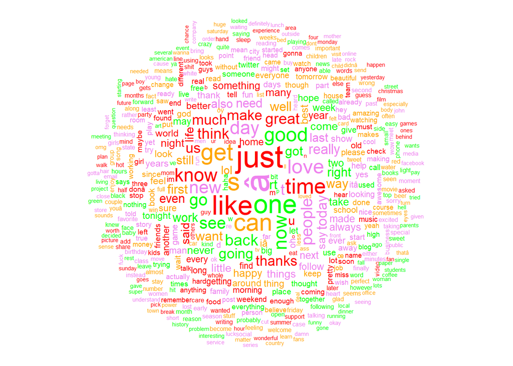

```r
#Compressing as cbind might result in duplicates in the dfm

bigDFM<-dfm_compress(bigDFM)

textplot_wordcloud(bigDFM,random_color = TRUE,color = c("Violet","Red","Green","Orange"))
```

The following is the list of top 20 most frequent words in the 3 datasets, with their frequencies:

```r
topfeatures(bigDFM,20)
```

```
##      â   just   like    one      s    can    get   time   love   good
## 300009 255351 224188 212498 199698 192097 186310 167405 151690 151110
##    now    day   know    new    see     go people   back  great      t
## 145839 142281 141370 129197 118389 116613 114475 110771 108051 104603
```